# Intermediate R

William Surles

2017-03-29

> This document was updated on **2017-03-31**.

# Introduction

- This all comes from the [Intermediate R](https://www.datacamp.com/courses/intermediate-r) course on DataCamp
  - I highly recommend the [DataCamp](https://www.datacamp.com/home) courses
  - Go *do* the [course](https://www.datacamp.com/courses/intermediate-r) for yourself to get more details and videos on these topics
- I am copying my work from the class to this document and adding comments

## Whats Covered

- Conditionals and Control Flow
  - Relational Operators. `==` `<` `>`
  - Logical Operators. `and` `or` `not`
  - Conditional Statements. `if` `else`
- Loops
  - While loops
  - For loops
  - Breaks
- Functions
  - Documentation
  - Required vs optional inputs
  - Scoping
  - Writing functions
  - Loading packages
- Apply statements
  - lapply, sapply, vapply
- Utilities
  - Useful base functions
  - Regular Expressions and grep/sub
  - Times and Dates

# Conditionals and Control Flow

## Relational Operators

- These are used to compare objects
- They are common in any langage and are a basis of programming

### Equality

```r
# Comparison of logicals
TRUE == FALSE
```

```
## [1] FALSE
```

```r
# Comparison of numerics
-6 * 14 != 17 - 101
```

```
## [1] FALSE
```

```r
# Comparison of character strings
"useR" == "user"
```

```
## [1] FALSE
```

```r
# Compare a logical with a numeric
TRUE == 1
```

```
## [1] TRUE
```

### Greater and less than

```r
# Comparison of numerics
-6 * 5 + 2 >= -10 + 1
```

```
## [1] FALSE
```

```r
# Comparison of character strings
"raining" <= "raining dogs"
```

```
## [1] TRUE
```

```r
# Comparison of logicals
TRUE > FALSE
```

```
## [1] TRUE
```

### Compare vectors

```r
# The linkedin and facebook vectors have already been created for you
linkedin <- c(16, 9, 13, 5, 2, 17, 14)
facebook <- c(17, 7, 5, 16, 8, 13, 14)

# Popular days
linkedin > 15
```

```
## [1]  TRUE FALSE FALSE FALSE FALSE  TRUE FALSE
```

```r
# Quiet days
linkedin <= 5
```

```
## [1] FALSE FALSE FALSE  TRUE  TRUE FALSE FALSE
```

```r
# LinkedIn more popular than Facebook
linkedin > facebook
```

```
## [1] FALSE  TRUE  TRUE FALSE FALSE  TRUE FALSE
```

### Compare matrices

```r
linkedin <- c(16, 9, 13, 5, 2, 17, 14)
facebook <- c(17, 7, 5, 16, 8, 13, 14)

views <- matrix(c(linkedin, facebook), nrow = 2, byrow = TRUE)

# When does views equal 13?
views == 13
```

```
##       [,1]  [,2]  [,3]  [,4]  [,5]  [,6]  [,7]
## [1,] FALSE FALSE  TRUE FALSE FALSE FALSE FALSE
## [2,] FALSE FALSE FALSE FALSE FALSE  TRUE FALSE
```

```r
# When is views less than or equal to 14?
views <= 14
```

```
##       [,1] [,2] [,3]  [,4] [,5]  [,6] [,7]
## [1,] FALSE TRUE TRUE  TRUE TRUE FALSE TRUE
## [2,] FALSE TRUE TRUE FALSE TRUE  TRUE TRUE
```

```r
# How often does facebook equal or exceed linkedin times two?
sum(facebook >= linkedin * 2)
```

```
## [1] 2
```

## Logical Operators

- These are also super common and a basis of programming
- They let us combine multiple relational statements

### & and |

```r
linkedin <- c(16, 9, 13, 5, 2, 17, 14)

last <- tail(linkedin, 1)

# Is last under 5 or above 10?
last < 5 | last > 10
```

```
## [1] TRUE
```

```r
# Is last between 15 (exclusive) and 20 (inclusive)?
last > 15 & last <= 20
```

```
## [1] FALSE
```

```r
# Is last between 0 and 5 or between 10 and 15?
(last > 0 & last < 5) | (last > 10 & last < 15)
```

```
## [1] TRUE
```

### & and | (2)

```r
linkedin <- c(16, 9, 13, 5, 2, 17, 14)
facebook <- c(17, 7, 5, 16, 8, 13, 14)

# linkedin exceeds 10 but facebook below 10
linkedin > 10 & facebook < 10
```

```
## [1] FALSE FALSE  TRUE FALSE FALSE FALSE FALSE
```

```r
# When were one or both visited at least 12 times?
linkedin > 12 | facebook > 12
```

```
## [1]  TRUE FALSE  TRUE  TRUE FALSE  TRUE  TRUE
```

```r
# When is views between 11 (exclusive) and 14 (inclusive)?
views > 11 & views <= 14
```

```
##       [,1]  [,2]  [,3]  [,4]  [,5]  [,6] [,7]
## [1,] FALSE FALSE  TRUE FALSE FALSE FALSE TRUE
## [2,] FALSE FALSE FALSE FALSE FALSE  TRUE TRUE
```

### Reverse the result: !

```r
!TRUE
```

```
## [1] FALSE
```

```r
!(5 > 3)
```

```
## [1] FALSE
```

```r
!!FALSE
```

```
## [1] FALSE
```

```r
x <- 5
y <- 7
!(!(x < 4) & !!!(y > 12))
```

```
## [1] FALSE
```

### Blend it all together

```r
second <- c(3, 23, 18, 18, 25, 20, 17, 27, 6, 35, 17, 6, 1, 12, 15, 17, 12, 8)

# Build a logical vector, TRUE if value in second is extreme: extremes
extremes <- second > 25 | second < 5

# Count the number of TRUEs in extremes
sum(extremes)
```

```
## [1] 4
```

## Conditional Statements

- Used to execute statements based on result of relational statements
- All of this is basis of programming and can be used in all the languages

### The if statement

```r
# Variables related to your last day of recordings
medium <- "LinkedIn"
num_views <- 14

# Examine the if statement for medium
if (medium == "LinkedIn") {
  print("Showing LinkedIn information")
}
```

```
## [1] "Showing LinkedIn information"
```

```r
# Write the if statement for num_views
if (num_views > 15) {
  print("You're popular!")
}
```

### And an else

```r
# Variables related to your last day of recordings
medium <- "LinkedIn"
num_views <- 14

# Control structure for medium
if (medium == "LinkedIn") {
  print("Showing LinkedIn information")
} else {
  print("Unknown medium")
}
```

```
## [1] "Showing LinkedIn information"
```

```r
# Control structure for num_views
if (num_views > 15) {
  print("You're popular!")
} else {
  print("Try to be more visible!")
}
```

```
## [1] "Try to be more visible!"
```

### Customize further: else if

```r
# Variables related to your last day of recordings
medium <- "LinkedIn"
num_views <- 14

# Control structure for medium
if (medium == "LinkedIn") {
  print("Showing LinkedIn information")
} else if (medium == "Facebook") {
  # Add code to print correct string when condition is True
  print("Showing Facebook information")
} else {
  print("Unknown medium")
}
```

```
## [1] "Showing LinkedIn information"
```

```r
# Control structure for num_views
if (num_views > 15) {
  print("You're popular!")
} else if (num_views <= 15 & num_views > 10) {
  # Add code to print correct string when condition is TRUE
  print("Your number of views is average")
} else {
  print("Try to be more visible!")
}
```

```
## [1] "Your number of views is average"
```

### Else if 2.0

```r
numbers <- c(6, 100, 4, 2500)

for (number in numbers) {

  if (number < 10) {
    if (number < 5) {
      result <- "extra small"
    } else {
      result <- "small"
    }
  } else if (number < 100) {
    result <- "medium"
  } else {
    result <- "large"
  }

  print(result)
}
```

```
## [1] "small"
## [1] "large"
## [1] "extra small"
## [1] "large"
```

### Take control!

```r
# Variables related to your last day of recordings
li <- 15
fb <- 9

# Code the control-flow construct
if (li >= 15 & fb >= 15) {
  sms <- (li + fb) * 2
} else if (li < 10 & fb < 10) {
  sms <- (li + fb) / 2
} else {
  sms <- (li + fb)
}

# Print the resulting sms to the console
print(sms)
```

```
## [1] 24
```

# Loops

## While loop

- it runs as long as the while condition is true

### Write a while loop

```r
# Initialize the speed variable
speed <- 64

# Code the while loop
while (speed > 30 ) {
  print('Slow down!')
  speed <- speed - 7
}
```

```
## [1] "Slow down!"
## [1] "Slow down!"
## [1] "Slow down!"
## [1] "Slow down!"
## [1] "Slow down!"
```

```r
print(speed)
```

```
## [1] 29
```

### Throw in more conditionals

```r
# Initialize the speed variable
speed <- 64

# Extend/adapt the while loop
while (speed > 30) {
  print(paste("Your speed is",speed))
  if (speed > 48) {
    print("Slow down big time!")
    speed <- speed - 11
  } else {
    print("Slow down!")
    speed <- speed - 6
  }
}
```

```
## [1] "Your speed is 64"
## [1] "Slow down big time!"
## [1] "Your speed is 53"
## [1] "Slow down big time!"
## [1] "Your speed is 42"
## [1] "Slow down!"
## [1] "Your speed is 36"
## [1] "Slow down!"
```

### Stop the while loop: break

```r
# Initialize the speed variable
speed <- 88

while (speed > 30) {
  print(paste("Your speed is",speed))

  # Break the while loop when speed exceeds 80
  if (speed > 80) {
    break
  }

  if (speed > 48) {
    print("Slow down big time!")
    speed <- speed - 11
  } else {
    print("Slow down!")
    speed <- speed - 6
  }
}
```

```
## [1] "Your speed is 88"
```

### Build a while loop from scratch

```r
# Initialize i as 1
i <- 1

# Code the while loop
while (i <= 10) {
  triple <- i * 3
  print(triple)

  if (triple %% 8 == 0) {
    break
  }
  i <- i + 1
}
```

```
## [1] 3
## [1] 6
## [1] 9
## [1] 12
## [1] 15
## [1] 18
## [1] 21
## [1] 24
```

## For loop

- Run once for each variable in the list
  - This list can just be a sequence like 1:5 or variables in a list like a bunch of names
  - This is so fundamental to programming in any language
- However I actualy never use loops in R
  - I always modify data arrays with array functions. They are WAY faster
  - The apply functions covered later are one way to do it.
  - dplyr is the best way. All the loopig happens in C code so its super fast.
  - If you are looping on an array in R, you should probably rethink your approach.

### Loop over a vector

```r
# The linkedin vector has already been defined for you
linkedin <- c(16, 9, 13, 5, 2, 17, 14)

# Loop version 1
for (views in linkedin) {
  print(views)
}
```

```
## [1] 16
## [1] 9
## [1] 13
## [1] 5
## [1] 2
## [1] 17
## [1] 14
```

```r
# Loop version 2
for (i in 1:length(linkedin)) {
  print(linkedin[i])
}
```

```
## [1] 16
## [1] 9
## [1] 13
## [1] 5
## [1] 2
## [1] 17
## [1] 14
```

### Loop over a list

```r
# The nyc list is already specified
nyc <- list(pop = 8405837,
            boroughs = c("Manhattan", "Bronx", "Brooklyn", "Queens", "Staten Island"),
            capital = FALSE)

# Loop version 1
for (value in nyc) {
  print(value)
}
```

```
## [1] 8405837
## [1] "Manhattan"     "Bronx"         "Brooklyn"      "Queens"
## [5] "Staten Island"
## [1] FALSE
```

```r
# Loop version 2
for (i in 1:length(nyc)) {
  print(nyc[[i]])
}
```

```
## [1] 8405837
## [1] "Manhattan"     "Bronx"         "Brooklyn"      "Queens"
## [5] "Staten Island"
## [1] FALSE
```

### Loop over a matrix

```r
# The tic-tac-toe matrix has already been defined for you
ttt <- matrix(c("O", NA, "X", NA, "O", NA, "X", "O", "X"), nrow = 3, ncol = 3)

# define the double for loop
for (i in 1:nrow(ttt)) {
  for (j in 1:ncol(ttt)) {
  print(paste("On row",i,"and column",j,"the board contains",ttt[i,j]))
  }
}
```

```
## [1] "On row 1 and column 1 the board contains O"
## [1] "On row 1 and column 2 the board contains NA"
## [1] "On row 1 and column 3 the board contains X"
## [1] "On row 2 and column 1 the board contains NA"
## [1] "On row 2 and column 2 the board contains O"
## [1] "On row 2 and column 3 the board contains O"
## [1] "On row 3 and column 1 the board contains X"
## [1] "On row 3 and column 2 the board contains NA"
## [1] "On row 3 and column 3 the board contains X"
```

### Mix it up with control flow

```r
# The linkedin vector has already been defined for you
linkedin <- c(16, 9, 13, 5, 2, 17, 14)

# Code the for loop with conditionals
for (i in 1:length(linkedin)) {
  if (linkedin[i] > 10) {
    print("You're popular!")
  } else {
    print("Be more visible!")
  }
  print(linkedin[i])
}
```

```
## [1] "You're popular!"
## [1] 16
## [1] "Be more visible!"
## [1] 9
## [1] "You're popular!"
## [1] 13
## [1] "Be more visible!"
## [1] 5
## [1] "Be more visible!"
## [1] 2
## [1] "You're popular!"
## [1] 17
## [1] "You're popular!"
## [1] 14
```

### Next, you break it

```r
# The linkedin vector has already been defined for you
linkedin <- c(16, 9, 13, 5, 2, 17, 14)

# Extend the for loop
for (li in linkedin) {
  if (li > 10) {
    print("You're popular!")
  } else {
    print("Be more visible!")
  }

  # Add code to conditionally break iteration
  if (li > 16) {
    print("This is ridiculous, I'm outta here!")
    break
  }

  # Add code to conditionally skip iteration
  if (li < 5) {
    print("This is too embarrassing!")
    next
  }

  print(li)
}
```

```
## [1] "You're popular!"
## [1] 16
## [1] "Be more visible!"
## [1] 9
## [1] "You're popular!"
## [1] 13
## [1] "Be more visible!"
## [1] 5
## [1] "Be more visible!"
## [1] "This is too embarrassing!"
## [1] "You're popular!"
## [1] "This is ridiculous, I'm outta here!"
```

### Build a loop from scratch

```r
# Pre-defined variables
rquote <- "R's internals are irrefutably intriguing"
chars <- strsplit(rquote, split = "")[[1]]
chars
```

```
##  [1] "R" "'" "s" " " "i" "n" "t" "e" "r" "n" "a" "l" "s" " " "a" "r" "e"
## [18] " " "i" "r" "r" "e" "f" "u" "t" "a" "b" "l" "y" " " "i" "n" "t" "r"
## [35] "i" "g" "u" "i" "n" "g"
```

```r
# Your solution here
rcount <- 0
for (c in chars) {
  if (c == 'u') {
    break
  }
  if (c == 'r' | c == 'R') {
    rcount <- rcount + 1
  }
}

# Print the resulting rcount variable to the console
print(rcount)
```

```
## [1] 5
```

# Functions

### Introduction to Functions

- You have already been using these a bunch.

### Function documentation

```r
# Consult the documentation on the mean() function
# In Rstudio this will open the help window
?mean

# Inspect the arguments of the mean() function
args(mean)
```

```
## function (x, ...)
## NULL
```

### Use a function

```r
# The linkedin and facebook vectors have already been created for you
linkedin <- c(16, 9, 13, 5, 2, 17, 14)
facebook <- c(17, 7, 5, 16, 8, 13, 14)

# Calculate average number of views
avg_li <- mean(linkedin)
avg_fb <- mean(facebook)

# Inspect avg_li and avg_fb
avg_li
```

```
## [1] 10.85714
```

```r
avg_fb
```

```
## [1] 11.42857
```

```r
# Calculate the mean of linkedin minus facebook
mean(linkedin - facebook)
```

```
## [1] -0.5714286
```

### Use a function (2)

```r
# The linkedin and facebook vectors have already been created for you
linkedin <- c(16, 9, 13, 5, 2, 17, 14)
facebook <- c(17, 7, 5, 16, 8, 13, 14)

# Calculate the mean of the sum
avg_sum <- mean(linkedin + facebook)

# Calculate the trimmed mean of the sum
avg_sum_trimmed <- mean(linkedin + facebook, trim = 0.2)

# Inspect both new variables
avg_sum
```

```
## [1] 22.28571
```

```r
avg_sum_trimmed
```

```
## [1] 22.6
```

### Use a function (3)

```r
# The linkedin and facebook vectors have already been created for you
linkedin <- c(16, 9, 13, 5, NA, 17, 14)
facebook <- c(17, NA, 5, 16, 8, 13, 14)

# Basic average of linkedin
mean(linkedin)
```

```
## [1] NA
```

```r
mean(facebook)
```

```
## [1] NA
```

```r
# Advanced average of facebook
mean(linkedin, na.rm = T)
```

```
## [1] 12.33333
```

```r
mean(facebook, na.rm = T)
```

```
## [1] 12.16667
```

### Functions inside functions

```r
# The linkedin and facebook vectors have already been created for you
linkedin <- c(16, 9, 13, 5, NA, 17, 14)
facebook <- c(17, NA, 5, 16, 8, 13, 14)

# Calculate the mean absolute deviation
mean(abs(linkedin - facebook), na.rm = T)
```

```
## [1] 4.8
```

### Required, or optional?

- There are required and optional arguments to a function
- Some (or actually most) of the optional arguments have a default value
  - this will be set automatically
  - for example, `read.table` has `header = FALSE` by default

The begining of the `read.table` function definition looks like this:

`read.table(file, header = FALSE, sep = "", quote = "\"",...`

In the `read.table()` function:

- `file` is required
- `header`, `sep`, and `quote` are optional arguments
  - `header` is defaulted to `FALSE`
  - `sep` is defaulted to and empty string `""`
  - `quote` is defaulted to `"`
- You do not have to write all the argument names
  - `read.table("myfile.txt", TRUE, "-")` will work.
- But the order matters if you use that shortcut
  - `read.table("myfile.txt", "-", TRUE)` will throw an error.
- You can use any order if you specify all the names and values
  - `read.table("myfile.txt", sep = "-", header = TRUE)` will work.

## Writing Functions

### Write your own functions

```r
# Create a function pow_two()
pow_two <- function(x) {
 result <- x^2
 return(result)
}

# Use the function
pow_two(12)
```

```
## [1] 144
```

```r
# Create a function sum_abs()
sum_abs <- function(x, y) {
  result <- abs(x) + abs(y)
  return(result)
}

# Use the function
sum_abs(-2, 3)
```

```
## [1] 5
```

### Write your own functions (2)

```r
# Define the function hello()
hello <- function() {
  print('Hi there!')
  return(TRUE)
}

# Call the function hello()
hello()
```

```
## [1] "Hi there!"
```

```
## [1] TRUE
```

```r
# Define the function my_filter()
my_filter <- function(x) {
  if (x >=0) {
    return(x)
  } else {
    return(NULL)
  }
}

# Call the function my_filter() twice
my_filter(5)
```

```
## [1] 5
```

```r
my_filter(-5)
```

[output not shown]

### Write you own functions (3)

```r
# Extend the pow_two() function
pow_two <- function(x, print_info = T) {

  y <- x ^ 2

  if (print_info == T) {
    print(paste(x, 'to the power two equals',y))
  }

  return(y)
}

pow_two(5)
```

```
## [1] "5 to the power two equals 25"
```

```
## [1] 25
```

```r
pow_two(5, print_info=F)
```

```
## [1] 25
```

### Function scoping

- Variables defined inside a function are not available outside of that function
  - Nor are the variable names given to the input
  - Calling x or y outside of this function would fail

```r
pow_two <- function(x) {
  y <- x ^ 2
  return(y)
}
pow_two(4)
```

[output not shown]

### R passes arguments by value

- In other words, a function won’t change the original variable passed in

```r
triple <- function(x) {
  x <- 3*x
  x
}

a <- 5
triple(a)
```

```
## [1] 15
```

```r
a
```

```
## [1] 5
```

### R you functional?

```r
# The linkedin and facebook vectors have already been created for you
linkedin <- c(16, 9, 13, 5, 2, 17, 14)
facebook <- c(17, 7, 5, 16, 8, 13, 14)

# Define the interpret function
interpret <- function(x) {

 if (x > 15) {
   print("You're popular!")
   return(x)
 } else {
   print("Try to be more visible!")
   return(0)
 }

}

# Call the interpret function twice
interpret(linkedin[1])
```

```
## [1] "You're popular!"
```

```
## [1] 16
```

```r
interpret(facebook[2])
```

```
## [1] "Try to be more visible!"
```

```
## [1] 0
```

### R you functional? (2)

```r
# The linkedin and facebook vectors have already been created for you
linkedin <- c(16, 9, 13, 5, 2, 17, 14)
facebook <- c(17, 7, 5, 16, 8, 13, 14)

# The interpret() can be used inside interpret_all()
interpret <- function(num_views) {
  if (num_views > 15) {
    print("You're popular!")
    return(num_views)
  } else {
    print("Try to be more visible!")
    return(0)
  }
}

# Define the interpret_all() function
interpret_all <- function(x, show_sum = T) {

  sum_pop_views <- 0

  for (i in x) {
    y <- interpret(i)
    sum_pop_views <- sum_pop_views + y
  }

  if (show_sum == T) {
    return(sum_pop_views)
  } else {
    return(NULL)
  }

}

# Call the interpret_all() function on both linkedin and facebook
interpret_all(facebook)
```

```
## [1] "You're popular!"
## [1] "Try to be more visible!"
## [1] "Try to be more visible!"
## [1] "You're popular!"
## [1] "Try to be more visible!"
## [1] "Try to be more visible!"
## [1] "Try to be more visible!"
```

```
## [1] 33
```

```r
interpret_all(linkedin)
```

```
## [1] "You're popular!"
## [1] "Try to be more visible!"
## [1] "Try to be more visible!"
## [1] "Try to be more visible!"
## [1] "Try to be more visible!"
## [1] "You're popular!"
## [1] "Try to be more visible!"
```

```
## [1] 33
```

## R Packages

- Many great functions are available through packages
- The base package is installed with R and loaded when you start R
- The others you need to load yourself when you want them
- I think the reason R is so useful today is becasue it has amazing packages
  - Especially the ones made by Hadley Wicklam or the folks at Rstudio

### Load an R Package

```r
# The mtcars vectors have already been prepared for you
wt <- mtcars$wt
hp <- mtcars$hp

# Request the currently attached packages
search()
```

```
##  [1] ".GlobalEnv"        "package:ggplot2"   "package:codetools"
##  [4] "package:shiny"     "package:stats"     "package:graphics"
##  [7] "package:grDevices" "package:utils"     "package:datasets"
## [10] "package:methods"   "Autoloads"         "package:base"
```

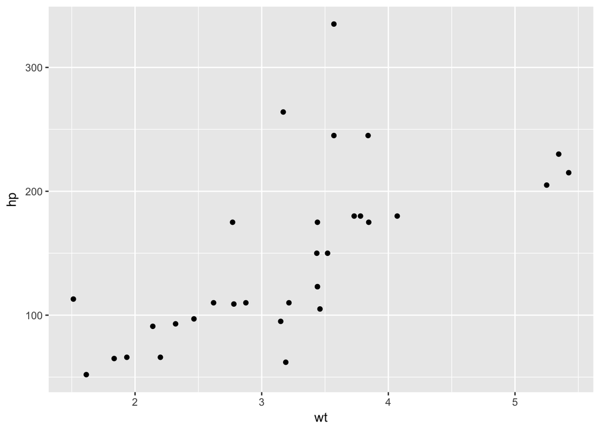

```r
# Load the ggplot2 package
library(ggplot2)

# Use the qplot() function.
# It will fail if you try before loading ggplot2 library
qplot(wt,hp)
```

```r
# Check out the currently attached packages again
search()
```

```
##  [1] ".GlobalEnv"        "package:ggplot2"   "package:codetools"
##  [4] "package:shiny"     "package:stats"     "package:graphics"
##  [7] "package:grDevices" "package:utils"     "package:datasets"
## [10] "package:methods"   "Autoloads"         "package:base"
```

### Different ways to load a package

- Its not picky. These all work.

```r
## I already have ggplot2 installed
## install.packages("ggplot2")

library(ggplot2)
library("ggplot2")
require(ggplot2)
```

# The apply family

### lapply

- applies a function to each element of a list/vector
- less code than writting out a whole loop
- also faster
- always returns a list
  - wrap in `unlist()` if you want a vector

### Use Lapply with a built-in R function

```r
# The vector pioneers has already been created for you
pioneers <- c("GAUSS:1777", "BAYES:1702", "PASCAL:1623", "PEARSON:1857")

# Split names from birth year: split_math
split_math <- strsplit(pioneers, ":")
split_math
```

```
## [[1]]
## [1] "GAUSS" "1777"
##
## [[2]]
## [1] "BAYES" "1702"
##
## [[3]]
## [1] "PASCAL" "1623"
##
## [[4]]
## [1] "PEARSON" "1857"
```

```r
# Convert to lowercase strings: split_low
split_low <- lapply(split_math, tolower)
split_low
```

```
## [[1]]
## [1] "gauss" "1777"
##
## [[2]]
## [1] "bayes" "1702"
##
## [[3]]
## [1] "pascal" "1623"
##
## [[4]]
## [1] "pearson" "1857"
```

```r
# Take a look at the structure of split_low
str(split_low)
```

```
## List of 4
##  $ : chr [1:2] "gauss" "1777"
##  $ : chr [1:2] "bayes" "1702"
##  $ : chr [1:2] "pascal" "1623"
##  $ : chr [1:2] "pearson" "1857"
```

```r
# For comparision, if you wrote out the whole loop
split_low2 <- list()

for (i in 1:length(split_math)) {
  split_low2[[i]] <- tolower(split_math[[i]])
}

split_low2
```

```
## [[1]]
## [1] "gauss" "1777"
##
## [[2]]
## [1] "bayes" "1702"
##
## [[3]]
## [1] "pascal" "1623"
##
## [[4]]
## [1] "pearson" "1857"
```

### Use lapply with your own function

```r
# Code from previous exercise:
pioneers <- c("GAUSS:1777", "BAYES:1702", "PASCAL:1623", "PEARSON:1857")
split <- strsplit(pioneers, split = ":")
split_low <- lapply(split, tolower)

# Write function select_first()
select_first <- function(x) {
  return(x[1])
}

# Apply select_first() over split_low: names
names <- lapply(split_low, select_first)
names
```

```
## [[1]]
## [1] "gauss"
##
## [[2]]
## [1] "bayes"
##
## [[3]]
## [1] "pascal"
##
## [[4]]
## [1] "pearson"
```

```r
# Write function select_second()
# Write function select_first()
select_second <- function(x) {
  return(x[2])
}

# Apply select_second() over split_low: years
years <- lapply(split_low, select_second)
years
```

```
## [[1]]
## [1] "1777"
##
## [[2]]
## [1] "1702"
##
## [[3]]
## [1] "1623"
##
## [[4]]
## [1] "1857"
```

### lapply and anonymous functions

```r
# Definition of split_low
pioneers <- c("GAUSS:1777", "BAYES:1702", "PASCAL:1623", "PEARSON:1857")
split <- strsplit(pioneers, split = ":")
split_low <- lapply(split, tolower)

names <- lapply(split_low, function(x) {x[1]})
years <- lapply(split_low, function(x) {x[2]})

names
```

```
## [[1]]
## [1] "gauss"
##
## [[2]]
## [1] "bayes"
##
## [[3]]
## [1] "pascal"
##
## [[4]]
## [1] "pearson"
```

```r
years
```

```
## [[1]]
## [1] "1777"
##
## [[2]]
## [1] "1702"
##
## [[3]]
## [1] "1623"
##
## [[4]]
## [1] "1857"
```

### Use lapply with additional arguments

```r
# Definition of split_low
pioneers <- c("GAUSS:1777", "BAYES:1702", "PASCAL:1623", "PEARSON:1857")
split <- strsplit(pioneers, split = ":")
split_low <- lapply(split, tolower)

# Replace the select_*() functions by a single function: select_el
select_el <- function(x,pos) {
  x[pos]
}

# Call the select_el() function twice on split_low: names and years
names <- lapply(split_low, select_el, 1)
years <- lapply(split_low, select_el, 2)

names
```

```
## [[1]]
## [1] "gauss"
##
## [[2]]
## [1] "bayes"
##
## [[3]]
## [1] "pascal"
##
## [[4]]
## [1] "pearson"
```

```r
years
```

```
## [[1]]
## [1] "1777"
##
## [[2]]
## [1] "1702"
##
## [[3]]
## [1] "1623"
##
## [[4]]
## [1] "1857"
```

### Apply functions that return NULL

```r
lapply(list(1, "a", TRUE), str)
```

```
##  num 1
##  chr "a"
##  logi TRUE
```

```r
str(list(1,"a",TRUE))
```

```
## List of 3
##  $ : num 1
##  $ : chr "a"
##  $ : logi TRUE
```

```r
str(TRUE)
```

```
##  logi TRUE
```

## sapply

- Stands for Simple apply
- Like lapply, but returns a vetor if it can
- It will name the vector by default
- If there are multiple outputs it will return a matrix
- If it can’t return a vector or matrix it will return a list
- Becareful with this if you expect a certain data type returned in a program

### How to use sapply

```r
# temp variable
temp <- list(
  c(3, 7,  9,  6, -1),
  c(6,  9, 12, 13,  5),
  c(4,  8,  3, -1, -3),
  c(1,  4,  7,  2, -2),
  c(5, 7, 9, 4, 2),
  c(-3,  5,  8,  9,  4),
  c(3, 6, 9, 4, 1)
  )

# Use lapply() to find each day's minimum temperature
lapply(temp, min)
```

```
## [[1]]
## [1] -1
##
## [[2]]
## [1] 5
##
## [[3]]
## [1] -3
##
## [[4]]
## [1] -2
##
## [[5]]
## [1] 2
##
## [[6]]
## [1] -3
##
## [[7]]
## [1] 1
```

```r
# Use sapply() to find each day's minimum temperature
sapply(temp, min)
```

```
## [1] -1  5 -3 -2  2 -3  1
```

```r
# Use lapply() to find each day's maximum temperature
lapply(temp, max)
```

```
## [[1]]
## [1] 9
##
## [[2]]
## [1] 13
##
## [[3]]
## [1] 8
##
## [[4]]
## [1] 7
##
## [[5]]
## [1] 9
##
## [[6]]
## [1] 9
##
## [[7]]
## [1] 9
```

```r
# Use sapply() to find each day's maximum temperature
sapply(temp, max)
```

```
## [1]  9 13  8  7  9  9  9
```

### sapply with your own function

```r
# temp is already defined in the workspace

# Define a function that calculates the average of the min and max of a vector: extremes_avg
extremes_avg <- function(x) {
 avg <- mean(c(min(x), max(x)))
 return(avg)
}

# Apply extremes_avg() over temp using sapply()
sapply(temp, extremes_avg)
```

```
## [1] 4.0 9.0 2.5 2.5 5.5 3.0 5.0
```

```r
# Apply extremes_avg() over temp using lapply()
lapply(temp, extremes_avg)
```

```
## [[1]]
## [1] 4
##
## [[2]]
## [1] 9
##
## [[3]]
## [1] 2.5
##
## [[4]]
## [1] 2.5
##
## [[5]]
## [1] 5.5
##
## [[6]]
## [1] 3
##
## [[7]]
## [1] 5
```

### sapply with function returning vector

```r
# temp is already available in the workspace

# Create a function that returns min and max of a vector: extremes

extremes <- function (x) {
  return(c(min(x),max(x)))
}

# Apply extremes() over temp with sapply()
sapply(temp, extremes)
```

```
##      [,1] [,2] [,3] [,4] [,5] [,6] [,7]
## [1,]   -1    5   -3   -2    2   -3    1
## [2,]    9   13    8    7    9    9    9
```

```r
# Apply extremes() over temp with lapply()
lapply(temp, extremes)
```

```
## [[1]]
## [1] -1  9
##
## [[2]]
## [1]  5 13
##
## [[3]]
## [1] -3  8
##
## [[4]]
## [1] -2  7
##
## [[5]]
## [1] 2 9
##
## [[6]]
## [1] -3  9
##
## [[7]]
## [1] 1 9
```

### sapply can’t simplify, now what?

```r
# temp is already prepared for you in the workspace

# Create a function that returns all values below zero: below_zero
below_zero <- function (x) {
 val <- x[x <0]
 return(val)
}

below_zero(c(1,2,3,-1,-1,-3))
```

```
## [1] -1 -1 -3
```

```r
# Apply below_zero over temp using sapply(): freezing_s
freezing_s <- sapply(temp, below_zero)
freezing_s
```

```
## [[1]]
## [1] -1
##
## [[2]]
## numeric(0)
##
## [[3]]
## [1] -1 -3
##
## [[4]]
## [1] -2
##
## [[5]]
## numeric(0)
##
## [[6]]
## [1] -3
##
## [[7]]
## numeric(0)
```

```r
# Apply below_zero over temp using lapply(): freezing_l
freezing_l <- lapply(temp, below_zero)
freezing_l
```

```
## [[1]]
## [1] -1
##
## [[2]]
## numeric(0)
##
## [[3]]
## [1] -1 -3
##
## [[4]]
## [1] -2
##
## [[5]]
## numeric(0)
##
## [[6]]
## [1] -3
##
## [[7]]
## numeric(0)
```

```r
# Compare freezing_s to freezing_l using identical()
identical(freezing_s, freezing_l)
```

```
## [1] TRUE
```

### sapply with functions that return NULL

```r
# temp is already available in the workspace

# Write a function that 'cat()s' out the average temperatures: print_info
print_info <- function (x) {
  cat("The average temperature is", mean(x), "\n")
}


# Apply print_info() over temp using lapply()
lapply(temp, print_info)
```

```
## The average temperature is 4.8
## The average temperature is 9
## The average temperature is 2.2
## The average temperature is 2.4
## The average temperature is 5.4
## The average temperature is 4.6
## The average temperature is 4.6
```

```r
# Apply print_info() over temp using sapply()
sapply(temp, print_info)
```

```
## The average temperature is 4.8
## The average temperature is 9
## The average temperature is 2.2
## The average temperature is 2.4
## The average temperature is 5.4
## The average temperature is 4.6
## The average temperature is 4.6
```

### Reverse engineering sapply

- this uses an anonymous function
- the result will have 3 rows and 2 columns

```r
sapply(list(runif (10), runif (10)),
       function(x) c(min = min(x), mean = mean(x), max = max(x)))
```

```
##           [,1]       [,2]
## min  0.1497697 0.03695026
## mean 0.4802390 0.56706037
## max  0.8623240 0.84919343
```

## vapply

- this is safer than sapply
  - becasue sapply can return a vector or a list (if result lengths differ)
- you can tell it what the return data type should be

### Use vapply

```r
# temp is already available in the workspace

# Code the basics() function
basics <- function (x) {
  return(c(min(x), mean(x), max(x)))
}

# Apply basics() over temp using vapply()
vapply(temp, basics, numeric(3))
```

```
##      [,1] [,2] [,3] [,4] [,5] [,6] [,7]
## [1,] -1.0    5 -3.0 -2.0  2.0 -3.0  1.0
## [2,]  4.8    9  2.2  2.4  5.4  4.6  4.6
## [3,]  9.0   13  8.0  7.0  9.0  9.0  9.0
```

### Use vapply (2)

```r
# temp is already available in the workspace

# Definition of the basics() function
basics <- function(x) {
  c(min = min(x), mean = mean(x), median = median(x), max = max(x))
}

# This time there are 4 values
vapply(temp, basics, numeric(4))
```

```
##        [,1] [,2] [,3] [,4] [,5] [,6] [,7]
## min    -1.0    5 -3.0 -2.0  2.0 -3.0  1.0
## mean    4.8    9  2.2  2.4  5.4  4.6  4.6
## median  6.0    9  3.0  2.0  5.0  5.0  4.0
## max     9.0   13  8.0  7.0  9.0  9.0  9.0
```

### From sapply to vapply

```r
# temp is already defined in the workspace
temp
```

```
## [[1]]
## [1]  3  7  9  6 -1
##
## [[2]]
## [1]  6  9 12 13  5
##
## [[3]]
## [1]  4  8  3 -1 -3
##
## [[4]]
## [1]  1  4  7  2 -2
##
## [[5]]
## [1] 5 7 9 4 2
##
## [[6]]
## [1] -3  5  8  9  4
##
## [[7]]
## [1] 3 6 9 4 1
```

```r
# sapply() expression
sapply(temp, max)
```

```
## [1]  9 13  8  7  9  9  9
```

```r
# Convert to vapply() expression
vapply(temp, max, numeric(1))
```

```
## [1]  9 13  8  7  9  9  9
```

```r
# sapply() expression
sapply(temp, function(x, y) { mean(x) > y }, y = 5)
```

```
## [1] FALSE  TRUE FALSE FALSE  TRUE FALSE FALSE
```

```r
# Convert to vapply() expression
vapply(temp, function(x, y) { mean(x) > y }, y = 5, logical(1))
```

```
## [1] FALSE  TRUE FALSE FALSE  TRUE FALSE FALSE
```

```r
# Definition of get_info (don't change)
get_info <- function(x, y) {
  if (mean(x) > y) {
    return("Not too cold!")
  } else {
    return("Pretty cold!")
  }
}

# sapply() expression
sapply(temp, get_info, y = 5)
```

```
## [1] "Pretty cold!"  "Not too cold!" "Pretty cold!"  "Pretty cold!"
## [5] "Not too cold!" "Pretty cold!"  "Pretty cold!"
```

```r
# Convert to vapply() expression
vapply(temp, get_info, y = 5, character(1))
```

```
## [1] "Pretty cold!"  "Not too cold!" "Pretty cold!"  "Pretty cold!"
## [5] "Not too cold!" "Pretty cold!"  "Pretty cold!"
```

# Utilities

### Useful Functions

The class video goes through some useful functions. I’ll list them here. There are many more than this.

- `abs()`
  - calc the absolute value of a vector
- `sum()`
  - calc the sum of a vector
- `mean()`
  - calc the mean value of a vector
- `seq()`
  - create a sequence
- `rep()`
  - repeat an array
- `sort()`
  - sort a vector
- `str()`
  - see the structure of your datatype
- `is.*()`, `as.*()`
  - check your data type of change it
- `append()`, `rev()`
  - append and reverse vectors

### Mathematical utilities

```r
# The errors vector has already been defined for you
errors <- c(1.9,-2.6,4.0,-9.5,-3.4,7.3)

# Sum of absolute rounded values of errors
sum(round(abs(errors)))
```

```
## [1] 29
```

### Find the error

```r
# Don't edit these two lines
vec1 <- c(1.5,2.5,8.4,3.7,6.3)
vec2 <- rev(vec1)

# Fix the error
mean(c(abs(vec1), abs(vec2)))
```

```
## [1] 4.48
```

### Data Utilities

```r
# The linkedin and facebook vectors have already been created for you
linkedin <- list(16, 9, 13, 5, 2, 17, 14)
facebook <- list(17, 7, 5, 16, 8, 13, 14)

# Convert linkedin and facebook to a vector: li_vec and fb_vec
li_vec <- as.numeric(linkedin)
fb_vec <- as.numeric(facebook)


# Append fb_vec to li_vec: social_vec
social_vec <- append(li_vec, fb_vec)
social_vec
```

```
##  [1] 16  9 13  5  2 17 14 17  7  5 16  8 13 14
```

```r
# Sort social_vec
sort(social_vec, decreasing=T)
```

```
##  [1] 17 17 16 16 14 14 13 13  9  8  7  5  5  2
```

### Find the error (2)

```r
# Fix me
round(sum(unlist(list(1.1,3,5))))
```

```
## [1] 9
```

```r
# Fix me
rep(seq(1, 7, by = 2), times = 7)
```

```
##  [1] 1 3 5 7 1 3 5 7 1 3 5 7 1 3 5 7 1 3 5 7 1 3 5 7 1 3 5 7
```

### Beat Gauss using R

```r
# Create first sequence: seq1
seq1 <- seq(1,500,by=3)
seq1
```

```
##   [1]   1   4   7  10  13  16  19  22  25  28  31  34  37  40  43  46  49
##  [18]  52  55  58  61  64  67  70  73  76  79  82  85  88  91  94  97 100
##  [35] 103 106 109 112 115 118 121 124 127 130 133 136 139 142 145 148 151
##  [52] 154 157 160 163 166 169 172 175 178 181 184 187 190 193 196 199 202
##  [69] 205 208 211 214 217 220 223 226 229 232 235 238 241 244 247 250 253
##  [86] 256 259 262 265 268 271 274 277 280 283 286 289 292 295 298 301 304
## [103] 307 310 313 316 319 322 325 328 331 334 337 340 343 346 349 352 355
## [120] 358 361 364 367 370 373 376 379 382 385 388 391 394 397 400 403 406
## [137] 409 412 415 418 421 424 427 430 433 436 439 442 445 448 451 454 457
## [154] 460 463 466 469 472 475 478 481 484 487 490 493 496 499
```

```r
# Create second sequence: seq2
seq2 <- seq(1200, 900, by=-7)
seq2
```

```
##  [1] 1200 1193 1186 1179 1172 1165 1158 1151 1144 1137 1130 1123 1116 1109
## [15] 1102 1095 1088 1081 1074 1067 1060 1053 1046 1039 1032 1025 1018 1011
## [29] 1004  997  990  983  976  969  962  955  948  941  934  927  920  913
## [43]  906
```

```r
# Calculate total sum of the sequences
sum(c(seq1, seq2))
```

```
## [1] 87029
```

## Regular Expressions

- These are just sequences of characters and meta-characters that can match a pattern
- They are used for
  - pattern existence
  - pattern replacement
  - pattern extraction

### grepl & grep

```r
# The emails vector has already been defined for you
emails <- c("john.doe@ivyleague.edu", "education@world.gov", "dalai.lama@peace.org",
            "invalid.edu", "quant@bigdatacollege.edu", "cookie.monster@sesame.tv")

# Use grepl() to match for "edu"
grepl("edu",emails)
```

```
## [1]  TRUE  TRUE FALSE  TRUE  TRUE FALSE
```

```r
# Use grep() to match for "edu", save result to hits
hits <- grep("edu",emails)
hits
```

```
## [1] 1 2 4 5
```

```r
# Subset emails using hits
emails[hits]
```

```
## [1] "john.doe@ivyleague.edu"   "education@world.gov"
## [3] "invalid.edu"              "quant@bigdatacollege.edu"
```

### grepl & grep (2)

```r
# The emails vector has already been defined for you
emails <- c("john.doe@ivyleague.edu", "education@world.gov", "dalai.lama@peace.org",
            "invalid.edu", "quant@bigdatacollege.edu", "cookie.monster@sesame.tv")

# Use grep() to match for .edu addresses more robustly
grep("@.*\\.edu$",emails)
```

```
## [1] 1 5
```

```r
# Use grepl() to match for .edu addresses more robustly, save result to hits
hits <- grepl("@.*\\.edu$",emails)
hits
```

```
## [1]  TRUE FALSE FALSE FALSE  TRUE FALSE
```

```r
# Subset emails using hits
emails[hits]
```

```
## [1] "john.doe@ivyleague.edu"   "quant@bigdatacollege.edu"
```

### sub and gsub

```r
# The emails vector has already been defined for you
emails <- c("john.doe@ivyleague.edu", "education@world.gov", "dalai.lama@peace.org",
            "invalid.edu", "quant@bigdatacollege.edu", "cookie.monster@sesame.tv")

# Use sub() to convert the email domains to datacamp.edu (attempt 1)
# The @ character is removed
sub("@.*\\.edu$","datacamp.edu",emails)
```

```
## [1] "john.doedatacamp.edu"     "education@world.gov"
## [3] "dalai.lama@peace.org"     "invalid.edu"
## [5] "quantdatacamp.edu"        "cookie.monster@sesame.tv"
```

```r
# Use sub() to convert the email domains to datacamp.edu (attempt 2)
# Thats better
sub("@.*\\.edu$","@datacamp.edu",emails)
```

```
## [1] "john.doe@datacamp.edu"    "education@world.gov"
## [3] "dalai.lama@peace.org"     "invalid.edu"
## [5] "quant@datacamp.edu"       "cookie.monster@sesame.tv"
```

### sub and gsub (2)

```r
awards <- c("Won 1 Oscar.",
  "Won 1 Oscar. Another 9 wins & 24 nominations.",
  "1 win and 2 nominations.",
  "2 wins & 3 nominations.",
  "Nominated for 2 Golden Globes. 1 more win & 2 nominations.",
  "4 wins & 1 nomination.")

sub(".*\\s([0-9]+)\\snomination.*$", "\\1", awards)
```

```
## [1] "Won 1 Oscar." "24"           "2"            "3"
## [5] "2"            "1"
```

## Times and Dates

### Right here, right now

```r
# Get the current date: today
today <- Sys.Date()

# See what today looks like under the hood
unclass(today)
```

```
## [1] 17256
```

```r
# Get the current time: now
now <- Sys.time()

# See what now looks like under the hood
unclass(now)
```

```
## [1] 1490983514
```

### Create and format times

- This will be helpful…
  - look up the format values in `strptime`.
  - e.g. `?strptime`
  - There are a lot

```r
# Definition of character strings representing dates
str1 <- "May 23, '96"
str2 <- "2012-3-15"
str3 <- "30/January/2006"

# Convert the strings to dates: date1, date2, date3
date1 <- as.Date(str1, format = "%b %d, '%y")
date2 <- as.Date(str2, format = "%Y-%m-%d")
date3 <- as.Date(str3, format = "%d/%B/%Y")

date1
```

```
## [1] "1996-05-23"
```

```r
date2
```

```
## [1] "2012-03-15"
```

```r
date3
```

```
## [1] "2006-01-30"
```

```r
# Convert dates to formatted strings

# Get the day of week
format(date1, "%A")
```

```
## [1] "Thursday"
```

```r
# Get the day of the month
format(date2, "%d")
```

```
## [1] "15"
```

```r
# Get the month abv and year
format(date3, "%b %Y")
```

```
## [1] "Jan 2006"
```

```r
# Definition of character strings representing times
str1 <- "May 23, '96 hours:23 minutes:01 seconds:45"
str2 <- "2012-3-12 14:23:08"

# Convert the strings to POSIXct objects: time1, time2
time1 <- as.POSIXct(str1, format = "%B %d, '%y hours:%H minutes:%M seconds:%S")
time2 <- as.POSIXct(str2, format = "%Y-%m-%d %T")

time1
```

```
## [1] "1996-05-23 23:01:45 EDT"
```

```r
time2
```

```
## [1] "2012-03-12 14:23:08 EDT"
```

```r
# Convert times to formatted strings

# Get the minnute
format(time1, "%M")
```

```
## [1] "01"
```

```r
# Get the hour:minute and AM/PM
format(time2, "%I:%M %p")
```

```
## [1] "02:23 PM"
```

### Calculations with Dates

```r
# day1, day2, day3, day4 and day5 are already available in the workspace
day1 <- as.Date("2017-03-12")
day2 <- as.Date("2017-03-14")
day3 <- as.Date("2017-03-19")
day4 <- as.Date("2017-03-25")
day5 <- as.Date("2017-03-30")

# Difference between last and first pizza day
day5-day1
```

```
## Time difference of 18 days
```

```r
# Create vector pizza
pizza <- c(day1, day2, day3, day4, day5)
pizza
```

```
## [1] "2017-03-12" "2017-03-14" "2017-03-19" "2017-03-25" "2017-03-30"
```

```r
# Create differences between consecutive pizza days: day_diff
day_diff <- diff(pizza)
day_diff
```

```
## Time differences in days
## [1] 2 5 6 5
```

```r
# Average period between two consecutive pizza days
mean(day_diff)
```

```
## Time difference of 4.5 days
```

### Calculations with Times

```r
# login and logout are already defined in the workspace
login <- c(as.POSIXct("2017-03-16 10:18:04 UTC"),
            as.POSIXct("2017-03-21 09:14:18 UTC"),
            as.POSIXct("2017-03-21 12:21:51 UTC"),
            as.POSIXct("2017-03-21 12:37:24 UTC"),
            as.POSIXct("2017-03-23 21:37:55 UTC"))

logout <- c(as.POSIXct("2017-03-16 10:56:29 UTC"),
            as.POSIXct("2017-03-21 09:14:52 UTC"),
            as.POSIXct("2017-03-21 12:35:48 UTC"),
            as.POSIXct("2017-03-21 13:17:22 UTC"),
            as.POSIXct("2017-03-23 22:08:47 UTC"))

# Calculate the difference between login and logout: time_online
time_online <- logout - login

# Inspect the variable time_online
time_online
```

```
## Time differences in secs
## [1] 2305   34  837 2398 1852
```

```r
# Calculate the total time online
sum(time_online)
```

```
## Time difference of 7426 secs
```

```r
# Calculate the average time online
mean(time_online)
```

```
## Time difference of 1485.2 secs
```

### Time is of the essence

```r
astro <- c("20-Mar-2015", "25-Jun-2015", "23-Sep-2015", "22-Dec-2015")
names(astro) <- c("spring", "summer","fall","winter")
astro
```

```
##        spring        summer          fall        winter
## "20-Mar-2015" "25-Jun-2015" "23-Sep-2015" "22-Dec-2015"
```

```r
meteo <- c("March 1, 15", "June 1, 15", "September 1, 15", "December 1, 15")
names(meteo) <- c("spring", "summer", "fall", "winter")
meteo
```

```
##            spring            summer              fall            winter
##     "March 1, 15"      "June 1, 15" "September 1, 15"  "December 1, 15"
```

```r
# Convert astro to vector of Date objects: astro_dates
astro_dates <- as.Date(astro, "%d-%b-%Y")
str(astro)
```

```
##  Named chr [1:4] "20-Mar-2015" "25-Jun-2015" "23-Sep-2015" ...
##  - attr(*, "names")= chr [1:4] "spring" "summer" "fall" "winter"
```

```r
str(astro_dates)
```

```
##  Date[1:4], format: "2015-03-20" "2015-06-25" "2015-09-23" "2015-12-22"
```

```r
# Convert meteo to vector of Date objects: meteo_dates
meteo_dates <- as.Date(meteo, "%B %d, %y")
str(meteo)
```

```
##  Named chr [1:4] "March 1, 15" "June 1, 15" "September 1, 15" ...
##  - attr(*, "names")= chr [1:4] "spring" "summer" "fall" "winter"
```

```r
str(meteo_dates)
```

```
##  Date[1:4], format: "2015-03-01" "2015-06-01" "2015-09-01" "2015-12-01"
```

```r
# Calculate the maximum absolute difference between astro_dates and meteo_dates
max(abs(astro_dates - meteo_dates))
```

```
## Time difference of 24 days
```

## The End

- Woof, thats a lot!
  - And thats just a sample of some key programming topics in R
- Theres a lot more to learn in each of those topics
  - Especially the funtions and packages
  - There are a lot of key packages to work with dataframes or times
  - There are packages for everything really
- This doc is useful to me as a reference
  - The class was best forlearning these things
  - Now I just need to see it again a few times to really get it
  - And I can look back here if ever need a little refresher in the future